# SEB task

2023-01-25

The data analysed in this document is related with direct marketing campaigns of a Portuguese banking institution. The marketing campaigns were based on phone calls. Often, more than one contact to the same client was required, in order to access if the product (bank term deposit) would be (or not) subscribed.  
The full dataset was described and analyzed in: S. Moro, R. Laureano and P. Cortez. Using Data Mining for Bank Direct Marketing: An Application of the CRISP-DM Methodology. In P. Novais et al. (Eds.), Proceedings of the European Simulation and Modelling Conference - ESM’2011, pp. 117-121, Guimarães, Portugal, October, 2011. EUROSIS. Available here: http://hdl.handle.net/1822/14838.

### 1. DATA MANIPULATION TASK

Demonstrate ability to:  
* select random subsample of data set;  
* filter desired rows using simple and more complex conditions;  
* drop unnecessary variables, rename some variables;  
* calculate summarizing statistics (for full sample and by categorical variables as well);  
* create new variables using simple transformation and custom functions;  
* order data set by several variables.

**1.1. Random subsample selection:**

```r
set.seed(567)
index_train <- sample(1:nrow(bank_full), 2/3 * nrow(bank_full))
training_set <-bank_full[index_train,]
test_set <- bank_full[-index_train, ]
head(training_set)
```

```
##       age         job  marital education default balance housing loan   contact
## 32069  77     retired divorced  tertiary      no    4659      no   no  cellular
## 15831  47 blue-collar  married   primary      no     273     yes   no  cellular
## 33642  29    services  married secondary      no       0     yes  yes  cellular
## 35093  38  management   single  tertiary      no     427     yes   no  cellular
## 17940  44  technician   single secondary      no    3438     yes   no telephone
## 38710  27      admin.   single  tertiary      no    3672     yes   no  cellular
##       day month duration campaign pdays previous poutcome   y
## 32069  14   apr      161        1    -1        0  unknown yes
## 15831  21   jul       91        3    -1        0  unknown  no
## 33642  20   apr      204        3    -1        0  unknown  no
## 35093   6   may       17        3   169        2  failure  no
## 17940  30   jul       68        2    -1        0  unknown  no
## 38710  15   may      157        2   351        5  failure  no
```

Here 66.67% of sample has been randomly split into training subset and test subset. This split will be used in task No. 3.

**1.2. Filtering desired rows using simple and more complex conditions:**

```r
head(bank_full[bank_full$age>65 & bank_full$job != "retired",])
```

```
##       age        job marital education default balance housing loan   contact
## 28907  66  housemaid married secondary      no    1929      no   no  cellular
## 29325  70 management married  tertiary      no   13297      no   no  cellular
## 30177  69 management married  tertiary      no     840      no   no telephone
## 30628  66 technician married secondary      no       0      no   no  cellular
## 30642  70 management married  tertiary      no    5563      no   no  cellular
## 31019  66 unemployed  single   primary      no    1323      no   no telephone
##       day month duration campaign pdays previous poutcome   y
## 28907   2   feb      169        1    -1        0  unknown  no
## 29325   2   feb      579        2    -1        0  unknown  no
## 30177   5   feb      128        3    -1        0  unknown yes
## 30628   6   feb      751        1    -1        0  unknown yes
## 30642   6   feb      146        1    -1        0  unknown  no
## 31019  10   feb      207       11    -1        0  unknown  no
```

The code above filters data rows of clients that can be retired (due to state pension age), but are marked as not retired.

```r
head(bank_full %>%
  select(age, job) %>%
  filter(between(age, 18, 64)))
```

```
##   age          job
## 1  58   management
## 2  44   technician
## 3  33 entrepreneur
## 4  47  blue-collar
## 5  33      unknown
## 6  35   management
```

The code above selects only `age` and `job` columns and filters `age` from 18 to 64 years.

```r
head(bank_full %>%
  filter(job %in% c("retired", "student") & y != 0 & housing == "yes" & poutcome == "success"))
```

```
##   age     job  marital education default balance housing loan  contact day
## 1  35 student   single secondary      no     188     yes   no cellular   5
## 2  29 student   single secondary      no     949     yes   no cellular  15
## 3  27 student   single  tertiary      no    3733     yes   no cellular  22
## 4  61 retired  married  tertiary      no    2557     yes   no cellular  11
## 5  53 retired divorced  tertiary      no    -309     yes   no cellular  21
## 6  28 student   single  tertiary      no    3733     yes   no cellular  21
##   month duration campaign pdays previous poutcome   y
## 1   may      863        1    78        8  success yes
## 2   may      109        2   352        1  success  no
## 3   may      198        1    98        6  success yes
## 4   aug      139        3   190        1  success yes
## 5   aug      343        2   428        2  success yes
## 6   aug      419        5    91        7  success  no
```

**1.3. Dropping unnecessary variables and renaming some of the variables:**

```r
colnames(select(bank_full, -c("pdays", "previous")))
```

```
##  [1] "age"       "job"       "marital"   "education" "default"   "balance"
##  [7] "housing"   "loan"      "contact"   "day"       "month"     "duration"
## [13] "campaign"  "poutcome"  "y"
```

During visualization part it was noticed that number of days that passed by after the client was last contacted from a previous campaign and number of contacts performed before this campaign and for this client do not seem to have a clear / material effect on a term deposit subscription.

```r
colnames(rename(bank_full, c(prev_out = poutcome, deposit = y)))
```

```
##  [1] "age"       "job"       "marital"   "education" "default"   "balance"
##  [7] "housing"   "loan"      "contact"   "day"       "month"     "duration"
## [13] "campaign"  "pdays"     "previous"  "prev_out"  "deposit"
```

or:

```r
ndat<-bank_full
colnames(ndat)[16:17] <- c("prev_out", "deposit")
colnames(ndat)[16:17]
```

```
## [1] "prev_out" "deposit"
```

**1.4. Calculation of summarizing statistics (for full sample and categorical variables):**

```r
summary(bank_full)
```

```
##       age            job              marital           education
##  Min.   :18.00   Length:45211       Length:45211       Length:45211
##  1st Qu.:33.00   Class :character   Class :character   Class :character
##  Median :39.00   Mode  :character   Mode  :character   Mode  :character
##  Mean   :40.94
##  3rd Qu.:48.00
##  Max.   :95.00
##    default             balance         housing              loan
##  Length:45211       Min.   : -8019   Length:45211       Length:45211
##  Class :character   1st Qu.:    72   Class :character   Class :character
##  Mode  :character   Median :   448   Mode  :character   Mode  :character
##                     Mean   :  1362
##                     3rd Qu.:  1428
##                     Max.   :102127
##    contact               day           month              duration
##  Length:45211       Min.   : 1.00   Length:45211       Min.   :   0.0
##  Class :character   1st Qu.: 8.00   Class :character   1st Qu.: 103.0
##  Mode  :character   Median :16.00   Mode  :character   Median : 180.0
##                     Mean   :15.81                      Mean   : 258.2
##                     3rd Qu.:21.00                      3rd Qu.: 319.0
##                     Max.   :31.00                      Max.   :4918.0
##     campaign          pdays          previous          poutcome
##  Min.   : 1.000   Min.   : -1.0   Min.   :  0.0000   Length:45211
##  1st Qu.: 1.000   1st Qu.: -1.0   1st Qu.:  0.0000   Class :character
##  Median : 2.000   Median : -1.0   Median :  0.0000   Mode  :character
##  Mean   : 2.764   Mean   : 40.2   Mean   :  0.5803
##  3rd Qu.: 3.000   3rd Qu.: -1.0   3rd Qu.:  0.0000
##  Max.   :63.000   Max.   :871.0   Max.   :275.0000
##       y
##  Length:45211
##  Class :character
##  Mode  :character
##
##
##
```

```r
table1(~factor(job) + factor(marital) + factor(education) + factor(default) + factor(housing) + factor(loan) + factor(contact) + factor(poutcome) + factor(month)| factor(y), data = bank_full, na.rm = TRUE, digits = 1, format.number = TRUE)
```

|  | no (N=39922) | yes (N=5289) | Overall (N=45211) |
| --- | --- | --- | --- |
| factor(job) |  |  |  |
| admin. | 4540 (11.4%) | 631 (11.9%) | 5171 (11.4%) |
| blue-collar | 9024 (22.6%) | 708 (13.4%) | 9732 (21.5%) |
| entrepreneur | 1364 (3.4%) | 123 (2.3%) | 1487 (3.3%) |
| housemaid | 1131 (2.8%) | 109 (2.1%) | 1240 (2.7%) |
| management | 8157 (20.4%) | 1301 (24.6%) | 9458 (20.9%) |
| retired | 1748 (4.4%) | 516 (9.8%) | 2264 (5.0%) |
| self-employed | 1392 (3.5%) | 187 (3.5%) | 1579 (3.5%) |
| services | 3785 (9.5%) | 369 (7.0%) | 4154 (9.2%) |
| student | 669 (1.7%) | 269 (5.1%) | 938 (2.1%) |
| technician | 6757 (16.9%) | 840 (15.9%) | 7597 (16.8%) |
| unemployed | 1101 (2.8%) | 202 (3.8%) | 1303 (2.9%) |
| unknown | 254 (0.6%) | 34 (0.6%) | 288 (0.6%) |
| factor(marital) |  |  |  |
| divorced | 4585 (11.5%) | 622 (11.8%) | 5207 (11.5%) |
| married | 24459 (61.3%) | 2755 (52.1%) | 27214 (60.2%) |
| single | 10878 (27.2%) | 1912 (36.2%) | 12790 (28.3%) |
| factor(education) |  |  |  |
| primary | 6260 (15.7%) | 591 (11.2%) | 6851 (15.2%) |
| secondary | 20752 (52.0%) | 2450 (46.3%) | 23202 (51.3%) |
| tertiary | 11305 (28.3%) | 1996 (37.7%) | 13301 (29.4%) |
| unknown | 1605 (4.0%) | 252 (4.8%) | 1857 (4.1%) |
| factor(default) |  |  |  |
| no | 39159 (98.1%) | 5237 (99.0%) | 44396 (98.2%) |
| yes | 763 (1.9%) | 52 (1.0%) | 815 (1.8%) |
| factor(housing) |  |  |  |
| no | 16727 (41.9%) | 3354 (63.4%) | 20081 (44.4%) |
| yes | 23195 (58.1%) | 1935 (36.6%) | 25130 (55.6%) |
| factor(loan) |  |  |  |
| no | 33162 (83.1%) | 4805 (90.8%) | 37967 (84.0%) |
| yes | 6760 (16.9%) | 484 (9.2%) | 7244 (16.0%) |
| factor(contact) |  |  |  |
| cellular | 24916 (62.4%) | 4369 (82.6%) | 29285 (64.8%) |
| telephone | 2516 (6.3%) | 390 (7.4%) | 2906 (6.4%) |
| unknown | 12490 (31.3%) | 530 (10.0%) | 13020 (28.8%) |
| factor(poutcome) |  |  |  |
| failure | 4283 (10.7%) | 618 (11.7%) | 4901 (10.8%) |
| other | 1533 (3.8%) | 307 (5.8%) | 1840 (4.1%) |
| success | 533 (1.3%) | 978 (18.5%) | 1511 (3.3%) |
| unknown | 33573 (84.1%) | 3386 (64.0%) | 36959 (81.7%) |
| factor(month) |  |  |  |
| apr | 2355 (5.9%) | 577 (10.9%) | 2932 (6.5%) |
| aug | 5559 (13.9%) | 688 (13.0%) | 6247 (13.8%) |
| dec | 114 (0.3%) | 100 (1.9%) | 214 (0.5%) |
| feb | 2208 (5.5%) | 441 (8.3%) | 2649 (5.9%) |
| jan | 1261 (3.2%) | 142 (2.7%) | 1403 (3.1%) |
| jul | 6268 (15.7%) | 627 (11.9%) | 6895 (15.3%) |
| jun | 4795 (12.0%) | 546 (10.3%) | 5341 (11.8%) |
| mar | 229 (0.6%) | 248 (4.7%) | 477 (1.1%) |
| may | 12841 (32.2%) | 925 (17.5%) | 13766 (30.4%) |
| nov | 3567 (8.9%) | 403 (7.6%) | 3970 (8.8%) |
| oct | 415 (1.0%) | 323 (6.1%) | 738 (1.6%) |
| sep | 310 (0.8%) | 269 (5.1%) | 579 (1.3%) |

Summary table for categorical variables show proportions (column overall) and split by clients who subscribed a term deposit (column *yes*) and not subscribed ones (column *no*). A couple of noticeable cases to mention:  
* Clients with tertiary education have higher share among the all clients that subscribed for a term deposit vs. share of such clients in a group of non-subscribed clients.  
* Out of total subscribed clients, the large share of clients (63.4%) did not have a housing loan, while for non-subscribed clients the larger part consist of clients with housing loan (58.1%).

**1.5. New variable creation by using simple transformation and custom functions:**

```r
head(bank_full %>% transmute(y = ifelse(bank_full$y=="yes",1,0),
                   default = ifelse(bank_full$default=="yes",1,0),
                   housing = ifelse(bank_full$housing=="yes",1,0),
                   loan = ifelse(bank_full$loan=="yes",1,0)))
```

```
##   y default housing loan
## 1 0       0       1    0
## 2 0       0       1    0
## 3 0       0       1    1
## 4 0       0       1    0
## 5 0       0       0    0
## 6 0       0       1    0
```

```r
head(bank_full %>% mutate(bal_month = ifelse(bank_full$balance > mean(bank_full$balance), 1, 0)))[,18]
```

```
## [1] 1 0 0 1 0 0
```

```r
head(bank_full$balance / 12)
```

```
## [1] 178.58333333   2.41666667   0.16666667 125.50000000   0.08333333
## [6]  19.25000000
```

The code above shows the following transformations: values of binary variables transformed into 0 and 1, also a new binary variable where value is equal to 1 if its greater than mean (1362 EUR) and equal to 0 if its value is bellow the mean and annual balance transformed to monthly balance.

**1.6. Data ordering by several variables:**

```r
head(bank_full[order(bank_full$job, bank_full$y),])
```

```
##    age    job  marital education default balance housing loan contact day month
## 11  41 admin. divorced secondary      no     270     yes   no unknown   5   may
## 12  29 admin.   single secondary      no     390     yes   no unknown   5   may
## 17  45 admin.   single   unknown      no      13     yes   no unknown   5   may
## 26  44 admin.  married secondary      no    -372     yes   no unknown   5   may
## 33  60 admin.  married secondary      no      39     yes  yes unknown   5   may
## 39  36 admin. divorced secondary      no     506     yes   no unknown   5   may
##    duration campaign pdays previous poutcome  y
## 11      222        1    -1        0  unknown no
## 12      137        1    -1        0  unknown no
## 17       98        1    -1        0  unknown no
## 26      172        1    -1        0  unknown no
## 33      208        1    -1        0  unknown no
## 39      577        1    -1        0  unknown no
```

```r
head(bank_full %>% arrange(job, desc(y), desc(marital)))
```

```
##   age    job marital education default balance housing loan contact day month
## 1  37 admin.  single secondary      no     245     yes  yes unknown   7   may
## 2  38 admin.  single secondary      no     100     yes   no unknown   7   may
## 3  49 admin.  single secondary      no     716     yes   no unknown  15   may
## 4  29 admin.  single secondary      no     163     yes  yes unknown  16   may
## 5  41 admin.  single secondary      no    1020     yes   no unknown  19   may
## 6  31 admin.  single secondary      no     431     yes  yes unknown  20   may
##   duration campaign pdays previous poutcome   y
## 1      732        2    -1        0  unknown yes
## 2      786        1    -1        0  unknown yes
## 3     1257        3    -1        0  unknown yes
## 4      803        1    -1        0  unknown yes
## 5      882        1    -1        0  unknown yes
## 6     1045        1    -1        0  unknown yes
```

### 2. DATA VISUALISATION TASK

In order to understand the data please visualize it. You are free to select the scope, types of plots, etc.

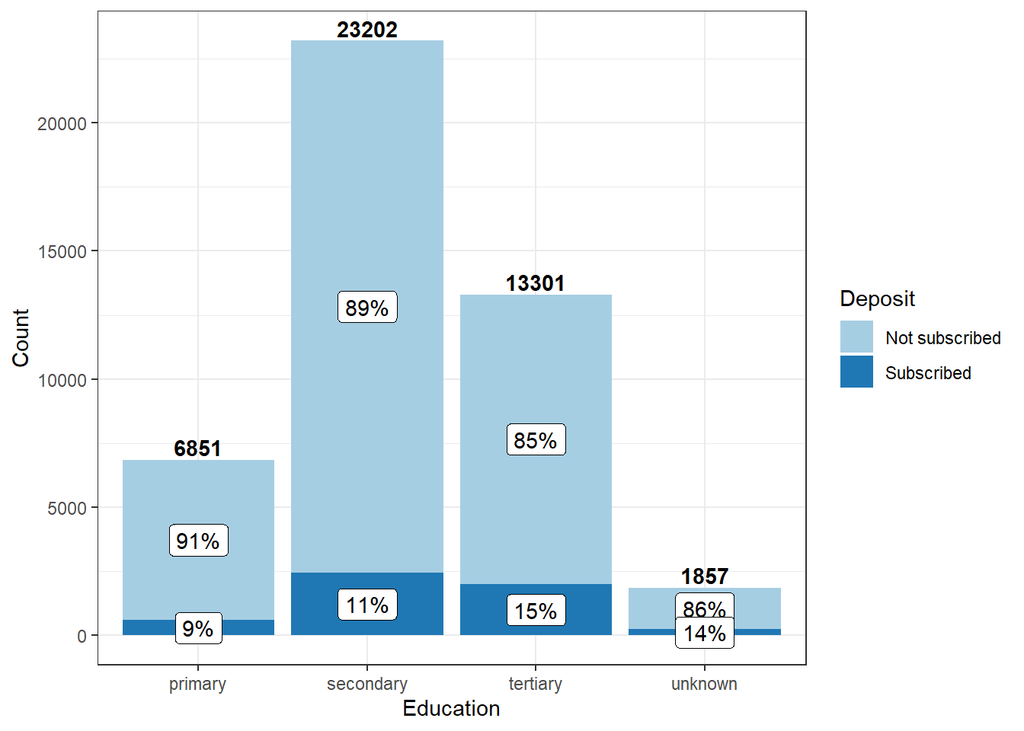

```r
education_y <- bank_full %>%
  group_by(education) %>%
  summarise(Count = n())


education_y_ratio <- bank_full %>%
  group_by(education, y) %>%
  summarise(Count = n()) %>%
  mutate(Percentage = round(Count/sum(Count)*100))


bank_full %>%
  ggplot() +
  geom_bar(aes(x = education, fill = y)) +
  geom_text(data = education_y,
            aes(x = education, y = Count, label = Count),
            position = position_dodge(width=0.9),
            vjust=-0.25,
            fontface = "bold") +
  geom_label(data = education_y_ratio,
             aes(x = education, y = Count, label = paste0(Percentage, "%"), group = y),
             position = position_stack(vjust = 0.5)) +
  theme_bw() +
  theme(plot.title = element_text(hjust = 0.5, size=18, color = "#054354")) +
  scale_x_discrete(name= "Education") +
  scale_y_continuous(name = "Count") +
  scale_fill_brewer(name = "Deposit", labels = c("Not subscribed", "Subscribed"), palette = "Paired")
```

From the bar plot above it is seen that clients that have tertiary education have a bit higher subscription share compared to other types of education (in particular, primary education).

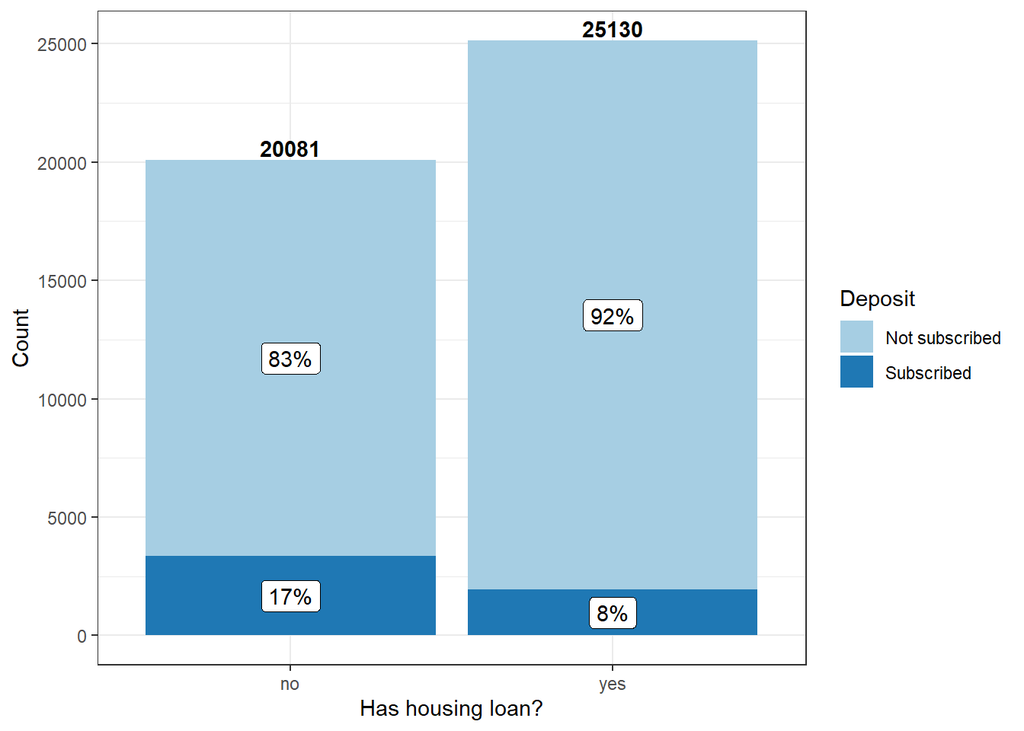

```r
housing_y <- bank_full %>%
  group_by(housing) %>%
  summarise(Count = n())


housing_y_ratio <- bank_full %>%
  group_by(housing, y) %>%
  summarise(Count = n()) %>%
  mutate(Percentage = round(Count/sum(Count)*100))


bank_full %>%
  ggplot() +
  geom_bar(aes(x = housing, fill = y)) +
  geom_text(data = housing_y,
            aes(x = housing, y = Count, label = Count),
            position = position_dodge(width=0.9),
            vjust=-0.25,
            fontface = "bold") +
  geom_label(data = housing_y_ratio,
             aes(x = housing, y = Count, label = paste0(Percentage, "%"), group = y),
             position = position_stack(vjust = 0.5)) +
  theme_bw() +
  theme(plot.title = element_text(hjust = 0.5, size=18, color = "#054354")) +
  scale_x_discrete(name= "Has housing loan?") +
  scale_y_continuous(name = "Count") +
  scale_fill_brewer(name = "Deposit", labels = c("Not subscribed", "Subscribed"), palette = "Paired")
```

It is seen that clients who do not have a housing loan are more keen to subscribe for a term deposit (17% vs. 8%). This might be because they have more money (less expenses) left to save compared to the ones that have a mortgage loan.

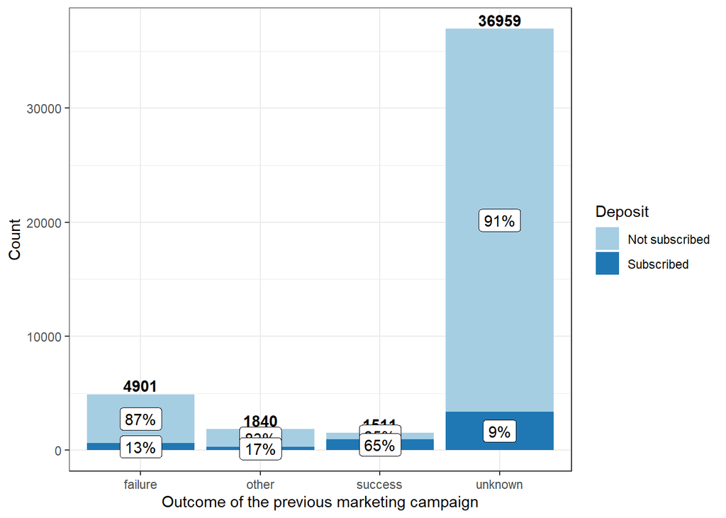

```r
poutcome_y <- bank_full %>%
  group_by(poutcome) %>%
  summarise(Count = n())


poutcome_y_ratio <- bank_full %>%
  group_by(poutcome, y) %>%
  summarise(Count = n()) %>%
  mutate(Percentage = round(Count/sum(Count)*100))


bank_full %>%
  ggplot() +
  geom_bar(aes(x = poutcome, fill = y)) +
  geom_text(data = poutcome_y,
            aes(x = poutcome, y = Count, label = Count),
            position = position_dodge(width=0.9),
            vjust=-0.25,
            fontface = "bold") +
  geom_label(data = poutcome_y_ratio,
             aes(x = poutcome, y = Count, label = paste0(Percentage, "%"), group = y),
             position = position_stack(vjust = 0.5)) +
  theme_bw() +
  theme(plot.title = element_text(hjust = 0.5, size=18, color = "#054354")) +
  scale_x_discrete(name= "Outcome of the previous marketing campaign") +
  scale_y_continuous(name = "Count") +
  scale_fill_brewer(name = "Deposit", labels = c("Not subscribed", "Subscribed"), palette = "Paired")
```

High share (65%) of clients that subscribed in previous marketing campaign also subscribed in this campaign.

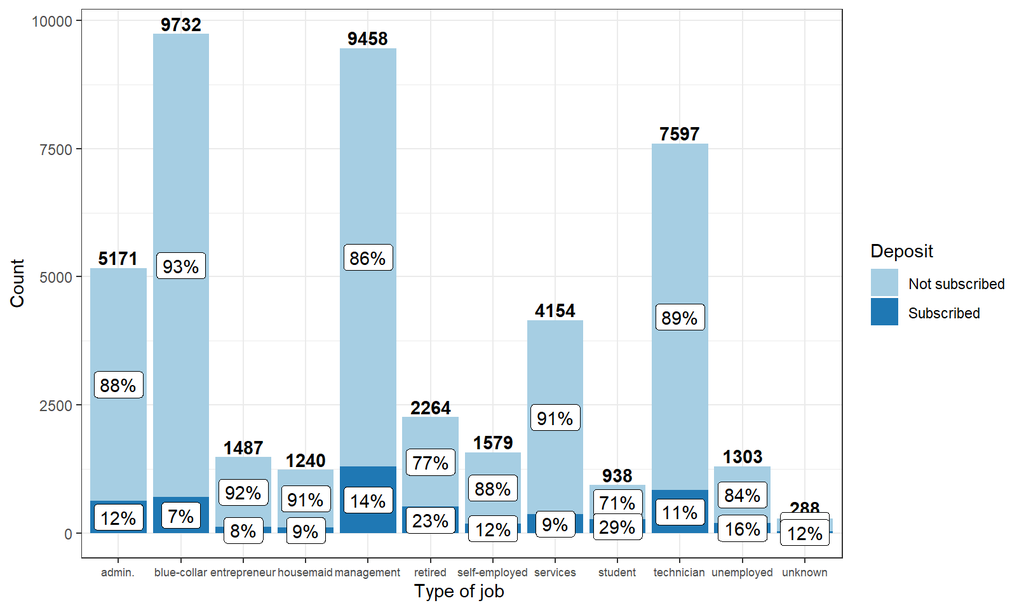

```r
job_y <- bank_full %>%
  group_by(job) %>%
  summarise(Count = n())


job_y_ratio <- bank_full %>%
  group_by(job, y) %>%
  summarise(Count = n()) %>%
  mutate(Percentage = round(Count/sum(Count)*100))


bank_full %>%
  ggplot() +
  geom_bar(aes(x = job, fill = y)) +
  geom_text(data = job_y,
            aes(x = job, y = Count, label = Count),
            position = position_dodge(width=0.9),
            vjust=-0.25,
            fontface = "bold") +
  geom_label(data = job_y_ratio,
             aes(x = job, y = Count, label = paste0(Percentage, "%"), group = y),
             position = position_stack(vjust = 0.5)) +
  theme_bw() +
  theme(plot.title = element_text(hjust = 0.5, size=18, color = "#054354"), axis.text.x=element_text(size=6.8)) +
  scale_x_discrete(name= "Type of job ") +
  scale_y_continuous(name = "Count") +
  scale_fill_brewer(name = "Deposit", labels = c("Not subscribed", "Subscribed"), palette = "Paired")
```

Students and retired clients are among the top ones that put a term deposit.

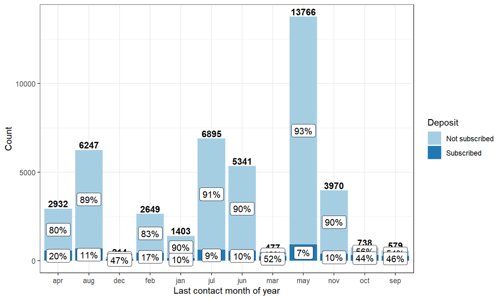

```r
month_y <- bank_full %>%
  group_by(month) %>%
  summarise(Count = n())


month_y_ratio <- bank_full %>%
  group_by(month, y) %>%
  summarise(Count = n()) %>%
  mutate(Percentage = round(Count/sum(Count)*100))


bank_full %>%
  ggplot() +
  geom_bar(aes(x = month, fill = y)) +
  geom_text(data = month_y,
            aes(x = month, y = Count, label = Count),
            position = position_dodge(width=0.9),
            vjust=-0.25,
            fontface = "bold") +
  geom_label(data = month_y_ratio,
             aes(x = month, y = Count, label = paste0(Percentage, "%"), group = y),
             position = position_stack(vjust = 0.5)) +
  theme_bw() +
  theme(plot.title = element_text(hjust = 0.5, size=18, color = "#054354")) +
  scale_x_discrete(name= "Last contact month of year") +
  scale_y_continuous(name = "Count") +
  scale_fill_brewer(name = "Deposit", labels = c("Not subscribed", "Subscribed"), palette = "Paired")
```

A higher share of subscriptions occurred in cases where the last contact was made on March, September, October and December.

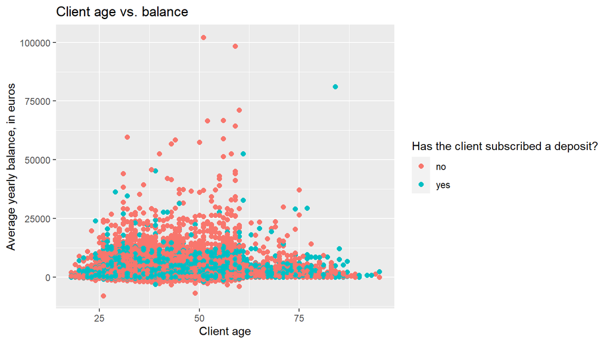

```r
ggplot(bank_full, aes(x=age, y=balance, color=y)) +
  geom_point(size=2)+
  labs(y = "Average yearly balance, in euros", x = "Client age", colour = "Has the client subscribed a deposit?")+
  ggtitle("Client age vs. balance")
```

The most of positive subscriptions concentrate bellow 2500 EUR yearly balance. Relation of positive subscriptions and `age` is not transparent.

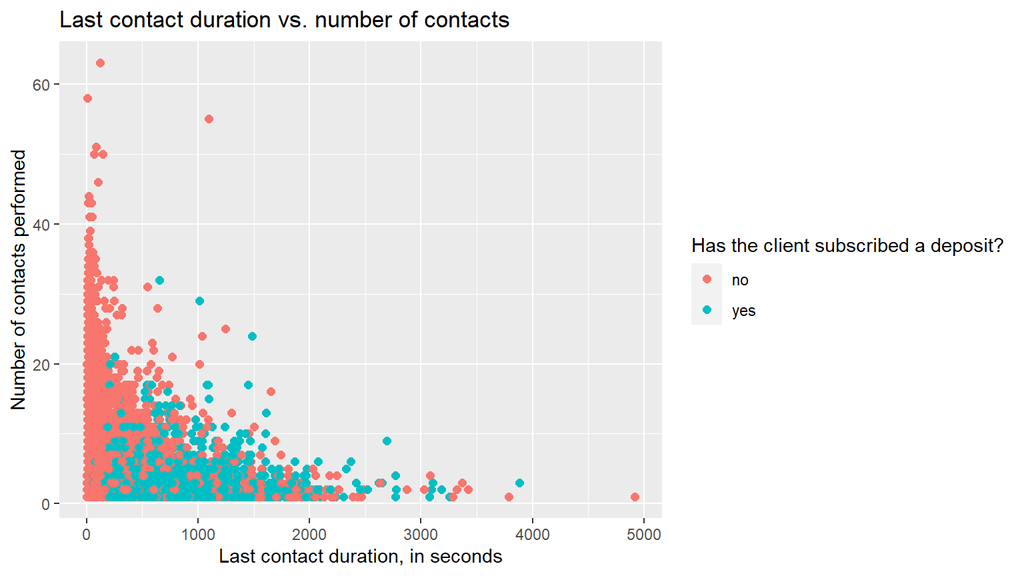

```r
ggplot(bank_full, aes(x=duration, y=campaign, color=y)) +
  geom_point(size=2)+
  labs(y = "Number of contacts performed", x = "Last contact duration, in seconds", colour = "Has the client subscribed a deposit?")+
  ggtitle("Last contact duration vs. number of contacts")
```

Here it is seen that very short duration of the contact can be a good indicator of non-subscribtion. Also, high number of contracts performed does not seem to work in terms of successfully signed term deposits.

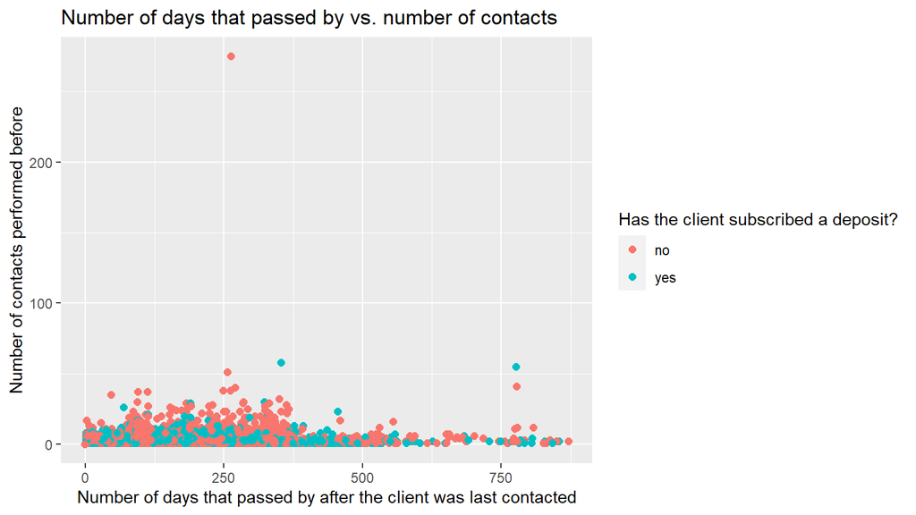

```r
ggplot(bank_full, aes(x=pdays, y=previous, color=y)) +
  geom_point(size=2)+
  labs(y = "Number of contacts performed before", x = "Number of days that passed by after the client was last contacted", colour = "Has the client subscribed a deposit?")+
  ggtitle("Number of days that passed by vs. number of contacts")
```

No explicit relations are seen with `pdays`, `previous` and positive term deposit subscriptions.

### 3. MODELLING TASK

Perform a logistic regression to obtain the predicted probability that a customer has subscribed for a term deposit.  
Use continuous variables and dummy variables created for categorical columns. Not necessarily all variables provided in data sample should be used.  
Evaluate model goodness of fit and predictive ability. If needed, data set could be split into training and test sets.  
The model was chosen considering several goodness of fit measurements, such as AIC criterion, deviance and Pseudo R².

```r
model<-glm(as.factor(y)~duration+balance+education+housing+poutcome+month, data = training_set, family = binomial)
summary(model)
```

```
##
## Call:
## glm(formula = as.factor(y) ~ duration + balance + education +
##     housing + poutcome + month, family = binomial, data = training_set)
##
## Deviance Residuals:
##     Min       1Q   Median       3Q      Max
## -5.6054  -0.3759  -0.2715  -0.1906   2.9897
##
## Coefficients:
##                      Estimate Std. Error z value Pr(>|z|)
## (Intercept)        -2.518e+00  1.121e-01 -22.461  < 2e-16 ***
## duration            4.046e-03  7.603e-05  53.221  < 2e-16 ***
## balance             1.758e-05  6.143e-06   2.862 0.004209 **
## educationsecondary  2.758e-01  7.144e-02   3.861 0.000113 ***
## educationtertiary   5.329e-01  7.435e-02   7.167 7.68e-13 ***
## educationunknown    3.208e-01  1.212e-01   2.646 0.008136 **
## housingyes         -8.963e-01  5.147e-02 -17.415  < 2e-16 ***
## poutcomeother       1.827e-01  1.088e-01   1.678 0.093292 .
## poutcomesuccess     2.357e+00  9.704e-02  24.293  < 2e-16 ***
## poutcomeunknown    -4.492e-01  6.866e-02  -6.542 6.05e-11 ***
## monthaug           -8.406e-01  9.251e-02  -9.087  < 2e-16 ***
## monthdec            5.145e-01  2.148e-01   2.395 0.016602 *
## monthfeb           -3.487e-01  1.029e-01  -3.390 0.000699 ***
## monthjan           -1.218e+00  1.479e-01  -8.238  < 2e-16 ***
## monthjul           -1.030e+00  9.418e-02 -10.942  < 2e-16 ***
## monthjun           -7.344e-01  9.594e-02  -7.655 1.94e-14 ***
## monthmar            1.700e+00  1.457e-01  11.663  < 2e-16 ***
## monthmay           -1.007e+00  8.325e-02 -12.091  < 2e-16 ***
## monthnov           -9.744e-01  1.035e-01  -9.414  < 2e-16 ***
## monthoct            8.154e-01  1.298e-01   6.281 3.36e-10 ***
## monthsep            7.063e-01  1.446e-01   4.886 1.03e-06 ***
## ---
## Signif. codes:  0 '***' 0.001 '**' 0.01 '*' 0.05 '.' 0.1 ' ' 1
##
## (Dispersion parameter for binomial family taken to be 1)
##
##     Null deviance: 21693  on 30139  degrees of freedom
## Residual deviance: 14887  on 30119  degrees of freedom
## AIC: 14929
##
## Number of Fisher Scoring iterations: 6
```

The fitted model summary showed the lowest AIC criteria value (14929) and deviance (14887).

```r
nagelkerke(model)
```

```
## $Models
##
## Model: "glm, as.factor(y) ~ duration + balance + education + housing + poutcome + month, binomial, training_set"
## Null:  "glm, as.factor(y) ~ 1, binomial, training_set"
##
## $Pseudo.R.squared.for.model.vs.null
##                              Pseudo.R.squared
## McFadden                             0.313732
## Cox and Snell (ML)                   0.202128
## Nagelkerke (Cragg and Uhler)         0.393917
##
## $Likelihood.ratio.test
##  Df.diff LogLik.diff  Chisq p.value
##      -20     -3402.9 6805.8       0
##
## $Number.of.observations
##
## Model: 30140
## Null:  30140
##
## $Messages
## [1] "Note: For models fit with REML, these statistics are based on refitting with ML"
##
## $Warnings
## [1] "None"
```

The model also had a higher Pseudo R² values compared with other models (these models are not included here, but some of examples are visible in the “raw” file).  
From fitting the model it was noticed that dropping `duration`, `balance`, `housing` variables reduces the goodness of fit of the model quite significantly.

```r
test_prob = predict(model, newdata = test_set, type = "response")
range(test_prob)
```

```
## [1] 0.00769782 0.99999545
```

It seen that the range of predicted probabilities is large therefore the created model seem to discriminate subscribed and non-subscribed clients quite well.

To measure predictive model performance, ROC and AUC metrics are used.

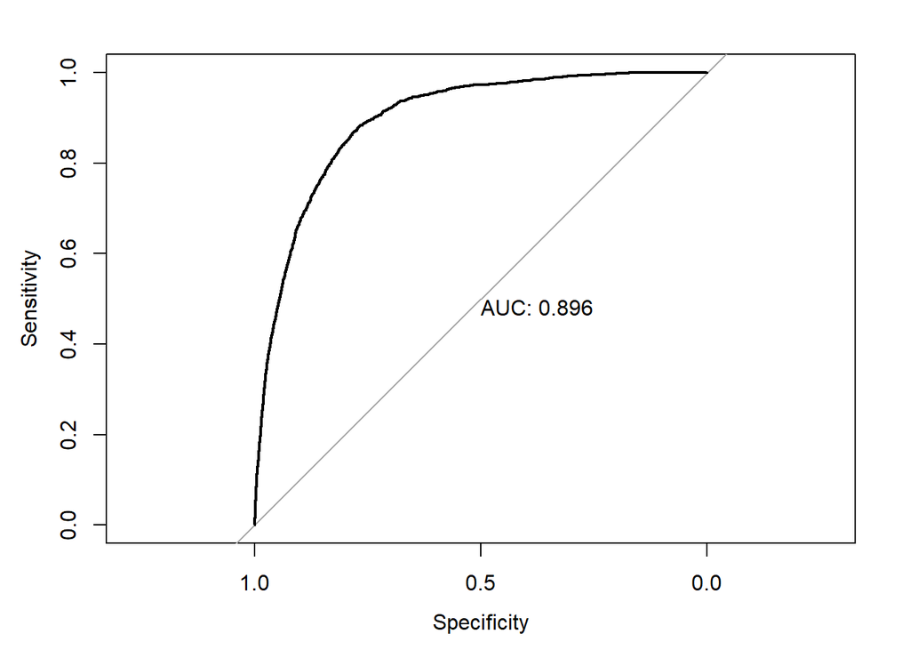

```r
test_roc = roc(test_set$y ~ test_prob, plot = TRUE, print.auc = TRUE)
```

```r
as.numeric(test_roc$auc)
```

```
## [1] 0.8963265
```

ROC curve shows relatively high sensitivity and specificity and AUC value (~0.9) indicates quite good model’s ability to distinguish between the subscribed and non-subscribed clients.